# Session 2 - Solutions

## Overview

This assignment introduces core mapping concepts in R using state-level U.S. data. You will progress from a static choropleth map to an interactive web map, learning how to join tabular data to spatial geometries and make thoughtful cartographic choices along the way.

## Learning Objectives

By the end of this assignment, you will be able to:

- Join non-spatial data to spatial geometries
- Create a static choropleth map using `ggplot2`
- Customize map appearance (color scales, labels, projections)
- Explain tradeoffs in common map design decisions
- Build an interactive map using `leaflet`

## Data

You are provided with a dataset called `state_data`, containing demographic and housing characteristics for:

- 50 U.S. states
- Washington, DC
- Puerto Rico

Each row represents a state or territory, identified by a **GEOID**. You will notice this is the same data from your first assignment. The code to produce `state_data` from `acs_data` is provided for you below:

```r
acs_data <- read_csv("../../Data/acs_data.csv")
clean_acs_metadata <- function(df) {

  df_clean <- df %>%
    rename(variable = name) %>%

    mutate(
      label_clean = label %>%
        str_remove("^Estimate!!") %>%
        str_replace_all("!!", "_") %>%
        str_replace_all("[^A-Za-z0-9_ ]", "") %>%
        str_replace_all(" +", "_") %>%
        str_to_lower(),

      concept_clean = concept %>%
        str_to_lower() %>%
        str_replace_all("[^a-z0-9 ]", "") %>%
        str_replace_all(" +", "_"),

      varname = paste0(concept_clean, "_", label_clean),
    ) %>%

    select(geoid, state, varname, estimate) %>%

    pivot_wider(
      id_cols = c(geoid, state),
      names_from = varname,
      values_from = estimate
    ) %>%

    relocate(geoid, state) %>%
    select(-`NA_NA`) %>%
  mutate(
    pct_owner = tenure_total_owner_occupied / tenure_total,
    pct_renter = tenure_total_renter_occupied / tenure_total
  )

  return(df_clean)
}

state_data <- clean_acs_metadata(acs_data)
```

## Task 1: Explore Simple Feature Data

Explore the following data:

```r
us_map()
```

```
## Simple feature collection with 52 features and 3 fields
## Geometry type: MULTIPOLYGON
## Dimension:     XY
## Bounding box:  xmin: -2584074 ymin: -2602555 xmax: 2516258 ymax: 731628.1
## Projected CRS: NAD27 / US National Atlas Equal Area
## First 10 features:
##    fips abbr                 full                           geom
## 1    02   AK               Alaska MULTIPOLYGON (((-2390688 -2...
## 2    01   AL              Alabama MULTIPOLYGON (((1091785 -13...
## 3    05   AR             Arkansas MULTIPOLYGON (((482022.2 -9...
## 4    04   AZ              Arizona MULTIPOLYGON (((-1386064 -1...
## 5    06   CA           California MULTIPOLYGON (((-1716581 -1...
## 6    08   CO             Colorado MULTIPOLYGON (((-787705.6 -...
## 7    09   CT          Connecticut MULTIPOLYGON (((2156162 -83...
## 8    11   DC District of Columbia MULTIPOLYGON (((1950799 -40...
## 9    10   DE             Delaware MULTIPOLYGON (((2037480 -28...
## 10   12   FL              Florida MULTIPOLYGON (((1853163 -20...
```

1. What is the shape of the data (number of columns and rows)?

Columns: 4 (3 and a geometry) Rows: 52 (50 states + PR + DC)

2. How does the dataset above differ from any other dataset?

It has a multipolygon geometry column. This is a list of spatial objects that make up each state. They are multipolygons because many geographies are not a single shape. They have islands, detached regions, holes, etc.

Think Michigan or Hawaii.

3. What is a simple feature object?

A spatial feature object is a data frame where each row represents a real-world feature and includes a geometry column describing its location or shape.

A spatial feature object is just a data frame where one column knows how to draw itself on a map.

4. What does the `Projected CRS: NAD27` mean?

Coordinated Reference System: North American Datum 1927

This tells us how to map our data. This happens to be quite an old model.

## Task 2: Join ACS Data with US Geometries

Load U.S. state geometries using the usmap package.

Join your tabular data to the geometries using the `geoid`.

```r
states_joined <- usmap::us_map(regions = "states") %>%
  left_join(state_data, by = c("fips" = "geoid"))
```

1. How many rows does the joined data have?

52

2. Do you see Washington, DC and Puerto Rico included? Why or why not?

Yes, because we had the data in both datasets, so they joined like any other state.

## Task 3: Create a Static Choropleth Map

Create a static map showing total population by state.

Use a continuous color scale.

Add a title and legend label.

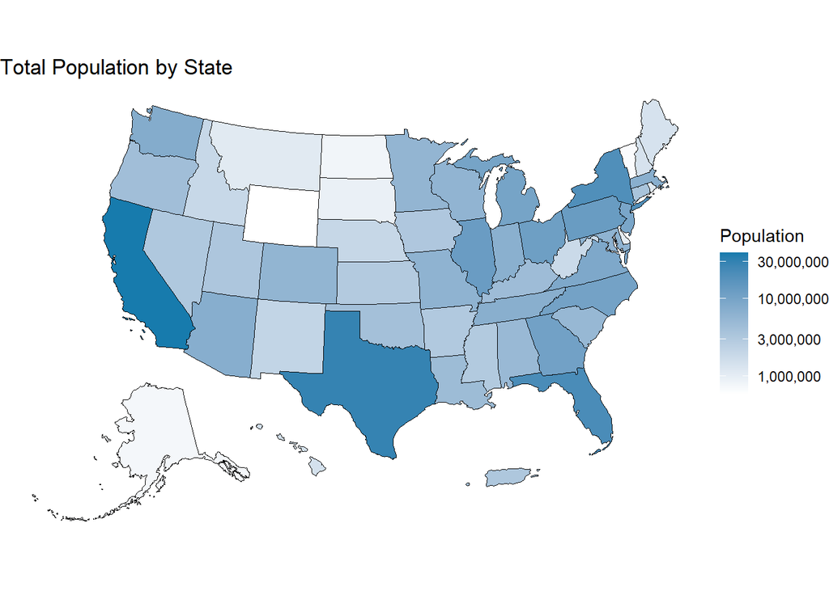

```r
ggplot(states_joined) +
  geom_sf(aes(fill = sex_by_age_total), color = "black", linewidth = 0.2) +
  # scale_fill_viridis_c() +
  scale_fill_continuous(
    low = "#FFFFFF",
    high = "#177BAD",
    transform = "log10",
    labels = comma) +
  # scale_fill_continuous(type = "viridis") +
  labs(
    title = "Total Population by State",
    fill = "Population") +
  theme_void()
```

```r
  # theme_minimal()
```

## Task 4: Create an Interactive Map

Create a leaflet map showing the percentage of renters in each state.

Add hover or click popups with state names and values.

Include a legend.

2. Why could we not use the data from our us_maps() function that we used earlier?

usmap() has a different projection that leaflet and also applies a custom transformation to Alaska and Hawaii to make an easy to read, US centric map. Leaflet, tigris, and most web maps use WGS 84 CRS or World Geodetic System 1984. This is standard latitude and longitude mapping.

## Challenge

Go to the [R Graph gallery](https://r-graph-gallery.com/) and the map section. Create a hexbin, cartogram, or bubble map with one or more variables in our dataset.

### Hexbin

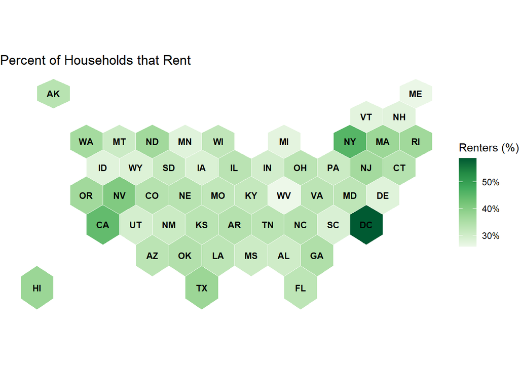

```r
my_sf <- read_sf("../../Data/us_states_hexgrid.geojson") %>%
  left_join(states_joined_leaflet %>%
              st_drop_geometry(), by = c("iso3166_2" ="STUSPS")) %>%
    mutate(centroid = st_centroid(geometry))

## Plot our data
ggplot(my_sf) +
  geom_sf(aes(fill = pct_renter), color = "white") +
  scale_fill_distiller(
    palette = "Greens",
    direction = 1,
    labels = scales::percent
  ) +
  geom_sf_text(
    aes(label = iso3166_2, geometry = centroid),
    size = 3,
    color = "black",
    fontface = "bold"
  ) +
  labs(
    title = "Percent of Households that Rent",
    fill = "Renters (%)"
  ) +
  theme_void()
```

Hexbins sacrifice geography for comparibility.

### Cartogram

```r
library(cartogram)
```

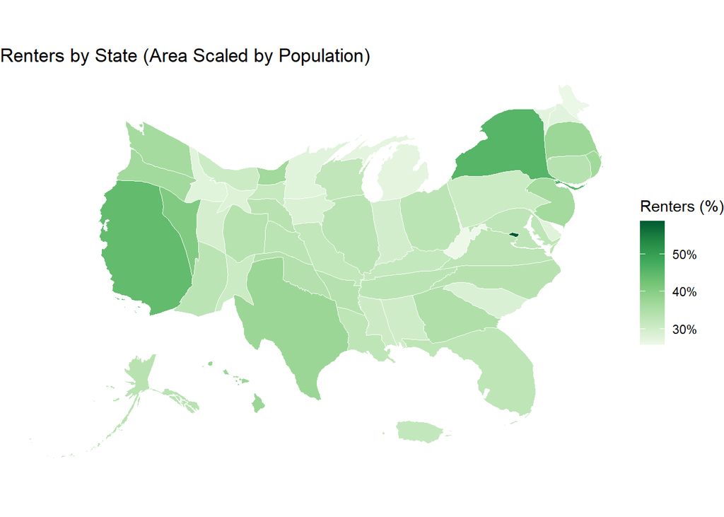

```r
states_cartogram <- cartogram_cont(
  states_joined,
  weight = "sex_by_age_total",
  itermax = 5
)

ggplot(states_cartogram) +
  geom_sf(aes(fill = pct_renter), color = "white", size = 0.2) +
  scale_fill_distiller(
    palette = "Greens",
    direction = 1,
    labels = scales::percent
  ) +
  labs(
    title = "Renters by State (Area Scaled by Population)",
    fill = "Renters (%)"
  ) +
  theme_void()
```

### Bubble Map

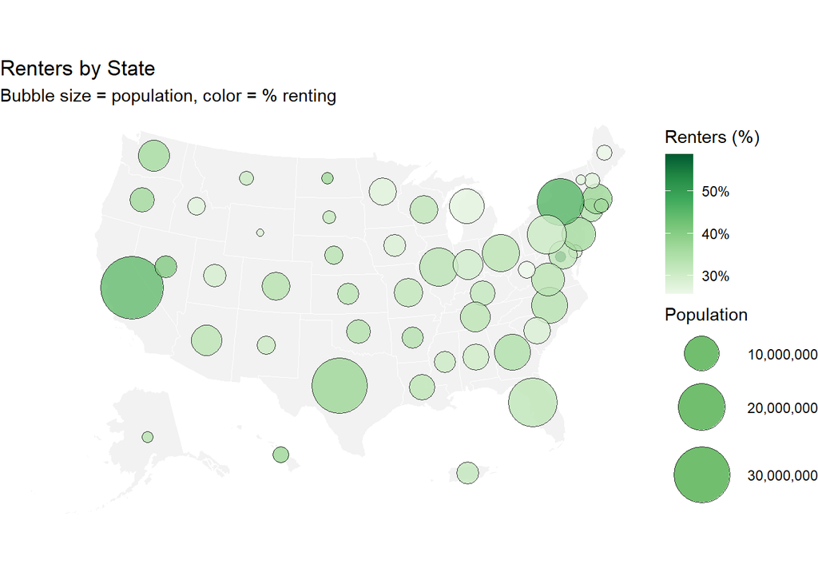

```r
# Create centroids
states_points <- states_joined %>%
  mutate(
    centroid = st_centroid(geom),
    lon = st_coordinates(centroid)[, 1],
    lat = st_coordinates(centroid)[, 2]
  )

states_sf <- usmap::us_map(regions = "states")

ggplot(states_points) +

  # base map
  geom_sf(data = states_sf, fill = "grey95", color = "white") +

  # bubbles
  geom_point(
    aes(
      x = lon,
      y = lat,
      size = sex_by_age_total,
      fill = pct_renter
    ),
    shape = 21,        # circle with outline + fill
    color = "black",   # outline color
    stroke = 0.5,
    alpha = 0.8
  ) +

  # size scale (population)
  scale_size(
    range = c(2, 18),
    labels = scales::comma
  ) +

  # fill scale (percent renters)
  scale_fill_distiller(
    palette = "Greens",
    direction = 1,
    labels = scales::percent
  ) +

  labs(
    title = "Renters by State",
    subtitle = "Bubble size = population, color = % renting",
    size = "Population",
    fill = "Renters (%)"
  ) +

    # Force the size legend bubbles to be green
  guides(
    size = guide_legend(
      override.aes = list(
        fill = "#4DAF4A",   # mid green
        color = "black"
      )
    )
  ) +

  coord_sf() +
  theme_void()
```

## Faceted Maps

```r
census_2010 <- read_csv("../../Data/Census Data 2010.csv") %>%
  mutate(year = 2010) %>%
  select(-'year == 2010')
census_2015 <- read_csv("../../Data/Census Data 2015.csv") %>%
  mutate(year = 2015) %>%
  select(-'year == 2015')
census_2020 <- read_csv("../../Data/Census Data 2020.csv") %>%
  mutate(year = 2020)
census_2023 <- read_csv("../../Data/Census Data 2023.csv") %>%
  mutate(year = 2023)
```

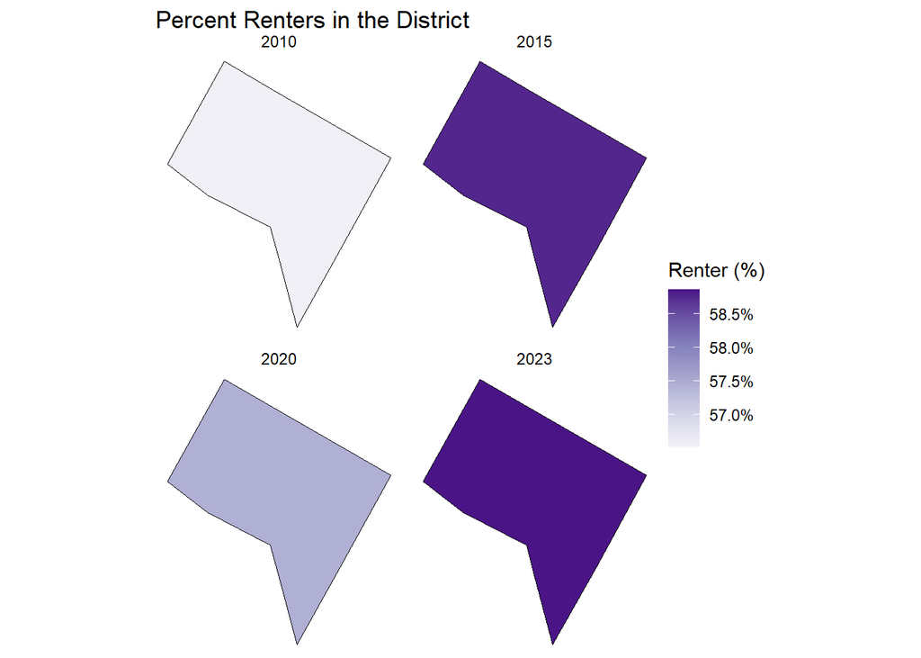

```r
census_tot <- rbind(census_2010,
                    census_2015,
                    census_2020,
                    # census_2021
                    # census_2022,
                    census_2023) %>%
  rename(geoid = GEOID,
         state = NAME)

clean_acs_metadata <- function(df) {

  df_clean <- df %>%
    rename(variable = name) %>%

    mutate(
      label_clean = label %>%
        str_remove("^Estimate!!") %>%
        str_replace_all("!!", "_") %>%
        str_replace_all("[^A-Za-z0-9_ ]", "") %>%
        str_replace_all(" +", "_") %>%
        str_to_lower(),

      concept_clean = concept %>%
        str_to_lower() %>%
        str_replace_all("[^a-z0-9 ]", "") %>%
        str_replace_all(" +", "_"),

      varname = paste0(concept_clean, "_", label_clean),
    ) %>%

    select(year, geoid, state, varname, estimate) %>%

    pivot_wider(
      id_cols = c(year, geoid, state),
      names_from = varname,
      values_from = estimate
    ) %>%

    relocate(geoid, state) %>%
    select(-`NA_NA`) %>%
  mutate(
    pct_owner = tenure_total_owner_occupied / tenure_total,
    pct_renter = tenure_total_renter_occupied / tenure_total
  )

  return(df_clean)
}


census_tot_clean <- clean_acs_metadata(census_tot)

census_tot_clean <- states_sf %>%
  filter(abbr %in% c("DC")) %>%
  left_join(census_tot_clean, by = c("fips" = "geoid"))


pop <- ggplot(census_tot_clean) +
  geom_sf(aes(fill = pct_renter), color = "black", linewidth = 0.2) +
  scale_fill_distiller(
    palette = "Purples",
    direction = 1,
    labels = scales::percent
  ) +
  labs(
    title = "Percent Renters in the District",
    fill = "Renter (%)") +
  theme_void()

pop +
  facet_wrap(~year)
```